# Religions of Linguists and Harassment

Author

Fadil Al-Husseini

## Introduction

In this report, we will be analyzing data from the Survey of Linguists and Language Researchers. We will look at the relationship with religion, identity, and experiencing harassment and isolation.

## Setup

```r
# install.packages("tidyverse")
# install.packages("here")
# install.packages("gt")
# install.packages("scales")
# install.packages("stringr")
# install.packages("readr")

library("tidyverse")
library("here")
library("gt")
library("scales")
library("stringr")
library("readr")

here::i_am("hp2quarto.qmd")
```

We install and load the packages that will be used for our analysis. The here function is used to find the qmd file.

```r
# CSV data is read into instance rawSurveyData
rawSurveyData <- read_csv(here("data/survey_of_linguists-r_ladies.csv"))
```

CSV data is loaded in.

## Codebook

| Variable Name | Data Type | Variable Label |
| --- | --- | --- |
| UNIQID | ID | Unique Participant ID |
| GenderSN | M/F/Other | Participant Gender |
| SexOrient_DC |  | Participant Sexual Orientation |
| Religion |  | Participant Religion |
| Bias_incidents |  | Witnessed Bias? |
| Bias_incidents_target |  | Experienced Bias? |
| Isolation_personal_identity |  | Isolated due to Identity? |

These are the relevant variables we will be working with for our analysis.

## Questions

### Which ten religions do most linguists follow?

To find this out, we’ll need to work with the UNIQID column and Religion column.

```r
religionData <- rawSurveyData %>%
  # Selects the ID and religion columns
  select(UNIQID, Religion) %>%
  # Separates the religion data by columns
  separate_longer_delim(Religion, delim = ",") %>%
  # Remove no response, prefer not to answer, & You don't
  filter(Religion != "NR"
         & Religion != "Prefer not to answer") %>%
  filter(!str_detect(Religion, 'You don')) %>%
  # Group by religion
  group_by(Religion) %>%
  # Counts the unique items & arranges it from most to least
  count(Religion) %>%
  arrange(desc(n)) %>%
  # Keeping the top 10 results for graphing
  filter(n > 7)
  # Standard deviation data
religionCount <- religionData %>%
  mutate(SD_data = sd(religionData$n))

religionCount$Religion[religionCount$Religion == "Spiritual but not religious"] <- "Spiritual"
religionCount$Religion[religionCount$Religion == "Latter Day Saints/Mormon"] <- "LDS"
  # Keeping column names short for graphing

religionCount
```

```
# A tibble: 10 × 3
# Groups:   Religion [10]
   Religion       n SD_data
   <chr>      <int>   <dbl>
 1 Atheist      451    140.
 2 Agnostic     274    140.
 3 Christian    123    140.
 4 Spiritual    119    140.
 5 Jewish        86    140.
 6 Catholic      73    140.
 7 Protestant    60    140.
 8 Buddhist      12    140.
 9 Muslim        11    140.
10 LDS            8    140.
```

After we select the columns and ensure that multiple responses are separated, e.g. a participant selecting both Jewish and atheist, the data was counted and the standard deviation was calculated.

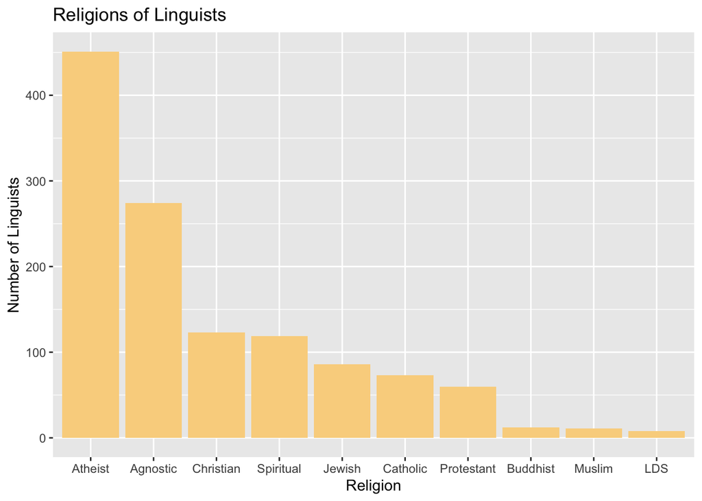

```r
religionCount %>%
  # Uses the Religion and reorders it by largest to smallest
  ggplot(aes(x = reorder(Religion, desc(n)), y = n)) +
  # Color and bar information
  geom_bar(stat="identity", fill = "#F9D48D") +
  # Label information
  labs(
    title = "Religions of Linguists",
  )+
  xlab("Religion") +
  ylab("Number of Linguists")
```

Now, we use a bar graph to model the data, going from largest to smallest. With the survey data, we see most linguists are atheist, agnostic, Christian, Spiritual but not religious, Jewish, Catholic, Protestant, Buddhist, Muslim, or Latter Day Saint.

### How does non-heterosexual orientation factor into this?

We use a similar process, but filter out results with “Heterosexual” selected.

```r
LGBTRData <- rawSurveyData %>%
  # Selects the ID and religion columns
  select(UNIQID, Religion, SexOrient_DC) %>%
  # Separates the religion data by columns
  separate_longer_delim(Religion, delim = ",") %>%
  # Remove no response, prefer not to answer, & You don't...
  filter(Religion != "NR"
         & Religion != "Prefer not to answer") %>%
  filter(!str_detect(Religion, 'You don')) %>%
  # Select for non-hetero
  filter(SexOrient_DC != "Heterosexual") %>%
  group_by(Religion) %>%
  # Counts the unique items & arranges it from most to least
  count(Religion) %>%
  arrange(desc(n))

# Add standard deviation data
LGBTReligionData <- LGBTRData %>%
  mutate(SD_data = sd(LGBTRData$n))

# Join both tables
bothData <- religionCount %>%
  left_join(LGBTReligionData, by = c("Religion" = "Religion")) %>%
  filter(!is.na(n.y))

bothData
```

```
# A tibble: 8 × 5
# Groups:   Religion [8]
  Religion     n.x SD_data.x   n.y SD_data.y
  <chr>      <int>     <dbl> <int>     <dbl>
1 Atheist      451      140.   164      50.7
2 Agnostic     274      140.   109      50.7
3 Christian    123      140.    30      50.7
4 Jewish        86      140.    25      50.7
5 Catholic      73      140.    23      50.7
6 Protestant    60      140.    15      50.7
7 Buddhist      12      140.     6      50.7
8 Muslim        11      140.     4      50.7
```

Now, we’ve created a table that includes the count and standard deviation of both the overall and non-heterosexual-only religion data.

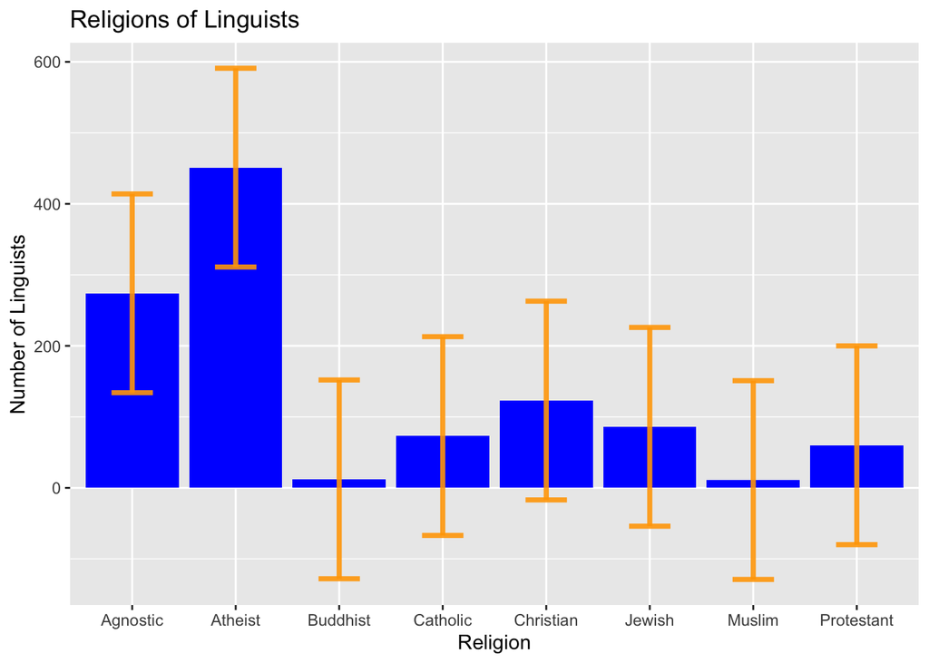

```r
bothData %>%
  ggplot(mapping = aes(x = Religion, y = n.x))+
  geom_bar(stat = "identity", fill = "blue")+
  geom_errorbar(aes(ymin = (n.x - SD_data.x), ymax= (n.x+SD_data.x)), width=0.4, colour="orange", alpha=0.9, linewidth=1.3)+
  labs(
    title = "Religions of Linguists",

  )+
  xlab("Religion") +
  ylab("Number of Linguists")
```

This plot includes both the number of linguists by religion and the error. There seems to be no statistical significance between the religions, except between atheism and non-agnosticism.

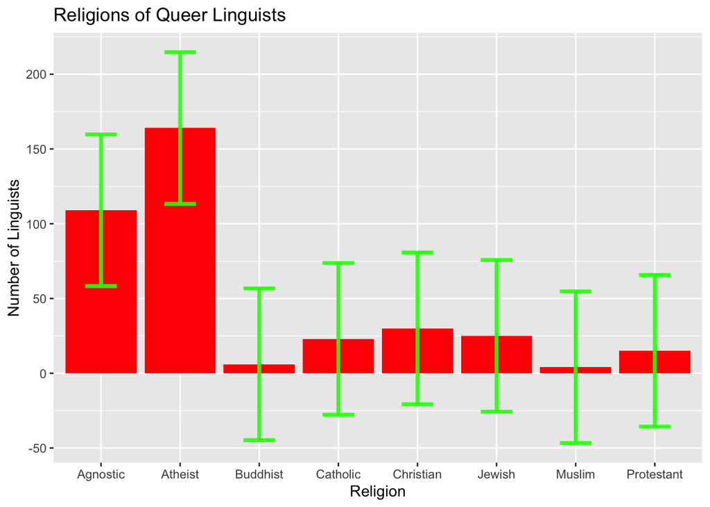

```r
bothData %>%
  ggplot(mapping = aes(x = Religion, y = n.y))+
  geom_bar(stat = "identity", fill = "red") +
  geom_errorbar(aes(ymin = (n.y - SD_data.y), ymax= (n.y+SD_data.y)), width=0.4, colour="green", alpha=0.9, linewidth=1.3)+
  labs(
    title = "Religions of Queer Linguists",

  )+
  xlab("Religion") +
  ylab("Number of Linguists")
```

This plot includes both the number of queer linguists by religion and the error.

Similar to the overall linguist plot, it seems that there is only a significant difference between linguists who identify as atheists and ones who don’t identify as agnostic, e.g. Catholic, Muslim, et cetera. This seems to indicate that sexual orientation does not play a role in religious identity among linguists.

For future work, more data on underrepresented religions may lead to more accurate results.

### How does religion relate to harassment, both experiencing and seeing?

To answer this question, we need to analyze religious data as it relates to observing bias incidents, experiencing bias incidents, and religion.

```r
biasIncidentData <- rawSurveyData %>%
  # Filter data
  filter(!is.na(Bias_incidents)) %>%
  filter(!is.na(Bias_incidents_target)) %>%
  filter(Bias_incidents != "NR") %>%
  filter(Bias_incidents_target != "NR") %>%
  filter(Religion != "NR"  & Religion != "Prefer not to answer" & Religion != "Prefer not to answer") %>%
  filter(!str_detect(Religion, 'You don')) %>%
  # Compute number of respondents in each grouping
  separate_longer_delim(Religion, delim = ",") %>%
  group_by(Religion, Bias_incidents, Bias_incidents_target) %>%
  summarize(num_respondents = n()) %>%
  ungroup() %>%
  # Compute number of respondents in overarching grouping
  group_by(Religion, Bias_incidents_target) %>%
  mutate(total_respondents = sum(num_respondents)) %>%
  ungroup() %>%
  # Compute percentage of respondents
  mutate(pct_respondents = num_respondents / total_respondents) %>%
  # Make the responses into factors
  mutate(Bias_incidents = factor(Bias_incidents,
                                 levels = c("Never",
                                            "Rarely",
                                            "Sometimes",
                                            "Often",
                                            "Constantly"))) %>%
  mutate(Bias_incidents_target = factor(Bias_incidents_target,
                                        levels = c("Never",
                                                   "Rarely",
                                                   "Sometimes",
                                                   "Often",
                                                   "Constantly")))
# Rename LDS and Spiritual
biasIncidentData$Religion[biasIncidentData$Religion == "Latter Day Saints/Mormon"] <- "LDS"
biasIncidentData$Religion[biasIncidentData$Religion == "Spiritual but not religious"] <- "Spiritual"
# Remove NA value
biasIncidentData <- biasIncidentData[-(98),]

biasIncidentData
```

```
# A tibble: 122 × 6
   Religion Bias_incidents Bias_incidents_target num_respondents
   <chr>    <fct>          <fct>                           <int>
 1 Agnostic Constantly     Constantly                          1
 2 Agnostic Constantly     Often                               4
 3 Agnostic Constantly     Rarely                              3
 4 Agnostic Never          Never                              15
 5 Agnostic Often          Never                               1
 6 Agnostic Often          Often                               8
 7 Agnostic Often          Rarely                              9
 8 Agnostic Often          Sometimes                          22
 9 Agnostic Rarely         Never                              34
10 Agnostic Rarely         Rarely                             45
# ℹ 112 more rows
# ℹ 2 more variables: total_respondents <int>, pct_respondents <dbl>
```

This tibble contains the religion, experience of harassment, observation of harassment, and the percentage from the respondents and total.

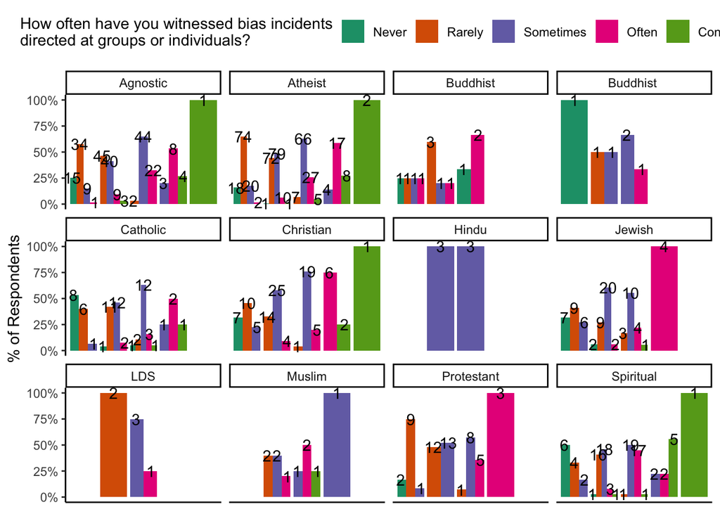

```r
biasIncidentData %>%
    # Initialize plot
  ggplot(aes(x = Bias_incidents_target,
             y = pct_respondents,
             fill = Bias_incidents)) +
  facet_wrap(~Religion) +
  # Add bars
  geom_bar(stat = "identity", position = "dodge") +
  # Add annotations for number of respondents in each bar
  geom_text(aes(label = num_respondents),
            position = position_dodge(width = 1)) +
  # Stylize plot
  scale_y_continuous(labels = percent) +
  scale_fill_brewer(palette = "Dark2") +
  labs(x = "How often have you been the target of bias incidents?",
       y = "% of Respondents",
       fill = "How often have you witnessed bias incidents\ndirected at groups or individuals?") +
  theme_classic() +
  theme(legend.position = "top",
        axis.title.x = element_blank(),
        axis.text.x = element_blank(),
        axis.ticks.x = element_blank())
```

Using the above data, we create this plot. The bar-groupings represent how often one has been a target of bias incidents.

We see that, across the data, there seems to be a trend wherein those who haven’t observed much harassment also tend not to experience harassment. This could be due to a multitude of factors: a person may not be able to identify harassment with others, making it more difficult to identify harassment against themselves; the environment may be safer, meaning no one experiences harassment in their workplace; et cetera.

It also seems that religion does not play a large role in harassment based on the presented data. As with the second question, having more data would allow us to make better predictions on the role of religion with harassment.

### How does religion relate to personal isolation?

Similar to the data above, we will look at responses for personal isolation as it relates to religion.

```r
religionIsolationPersonal <- rawSurveyData %>%
  # Filter NA data
  filter(!is.na(Isolation_personal_identity)) %>%
  filter(!is.na(Religion)) %>%
  # Filter out no response
  filter(Isolation_personal_identity != "NR") %>%
  # Create more rows in the case of multiple responses
  separate_longer_delim(Religion, delim = ",") %>%
  # Remove "Prefer not to Answer" and "NR"
  filter(Religion != "NR" & Religion != "Prefer not to answer") %>%
  # Remove 'other'
  filter(!str_detect(Religion, 'You don')) %>%
  # Select needed data
  select(UNIQID, Religion, Isolation_personal_identity)

# Group together 'Yes'
religionIsolationPersonal$Isolation_personal_identity[religionIsolationPersonal$Isolation_personal_identity == "Yes, I have been intentionally excluded"] <- "Yes"
religionIsolationPersonal$Isolation_personal_identity[religionIsolationPersonal$Isolation_personal_identity == "Yes, I have been excluded (perhaps intentionally)"] <- "Yes"
religionIsolationPersonal$Isolation_personal_identity[religionIsolationPersonal$Isolation_personal_identity == "Yes (other)"] <- "Yes"
# Rename LDS and Spiritual
religionIsolationPersonal$Religion[religionIsolationPersonal$Religion == "Latter Day Saints/Mormon"] <- "LDS"
religionIsolationPersonal$Religion[religionIsolationPersonal$Religion == "Spiritual but not religious"] <- "Spiritual"

# Group by the isolation response, religion, and count
religionIsoPData <- religionIsolationPersonal %>%
  group_by(Religion, Isolation_personal_identity) %>%
  # Counts the unique items & arranges it from most to least
  count(Religion, Isolation_personal_identity)

religionIsoPData
```

```
# A tibble: 35 × 3
# Groups:   Religion, Isolation_personal_identity [35]
   Religion    Isolation_personal_identity     n
   <chr>       <chr>                       <int>
 1 "Agnostic"  No                            126
 2 "Agnostic"  Not sure                       52
 3 "Agnostic"  Yes                            58
 4 "Atheist"   No                            218
 5 "Atheist"   Not sure                       73
 6 "Atheist"   Yes                           108
 7 "Buddhist"  No                              7
 8 "Buddhist"  Not sure                        2
 9 "Buddhist"  Yes                             3
10 "Buddhist " No                              2
# ℹ 25 more rows
```

Here we see that the tibble is organized by the religion and response regarding isolation. Those responses are then counted and grouped.

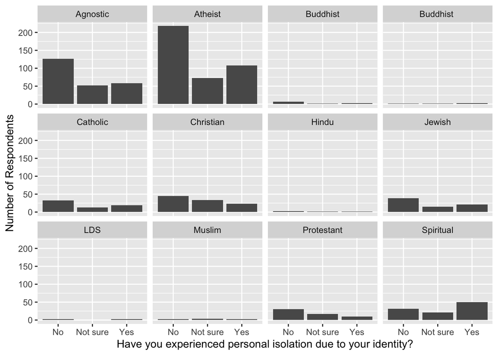

```r
religionIsoPData %>%
    # Initialize plot
  ggplot(aes(x = Isolation_personal_identity,
             y = n)) +
  facet_wrap(~Religion) +
  # Add bars
  geom_bar(stat = "identity", position = "dodge") +
  xlab("Have you experienced personal isolation due to your identity?") +
  ylab("Number of Respondents")
```

## Conclusion

For further reporters, more data on underrepresented religions may give us a better idea of harassment and isolation. In addition to that, questions that focus more on religious biases and inquiries may produce more reliable results, rather than focusing on identity generally.